# Prosper Loan Analysis

## Dataset Overview

> This project investigates the data from Prosper Loan which is a lending platform(Peer-to-Peer).The data set provides for various credentials and my analysis primarily revolves around the following variables:
1. *Loan Status* : The current status of the loan: Cancelled, Chargedoff, Current, Defaulted, FinalPaymentInProgress, PastDue. The PastDue status will be accompanied by a delinquency bucket.
2. *BorrowerAPR* : The Borrower's Annual Percentage Rate (APR) for the loan. This is equal to BorrowerRate + Loan Processing Charges.
3. *Term of the Loan*
4. *Employment Status of the loanee*
5. *Credit Score Range*
6. *Income range*
7. *Purpose of the loan*
8. *Debt to Income ratio* : The debt to income ratio of the borrower at the time the credit profile was pulled. This value is Null if the debt to income ratio is not available. This value is capped at 10.01 (any debt to income ratio larger than 1000% will be returned as 1001%).
9. *Original Amount of the Loan*
10. *Amount Delinquent*
11. *Prosper ratings* : The Prosper Rating assigned at the time the listing was created between AA - HR, with 'AA' being the best rating and 'HR' being the worst.. Applicable for loans originated after July 2009.
12. *Investors* : Number of Investors who funded the loan.
13. *Lender Yield*

```python
# import all packages and set plots to be embedded inline
import numpy as np
import pandas as pd
import matplotlib.pyplot as plt
import seaborn as sns

%matplotlib inline

# suppress warnings from final output
import warnings
warnings.simplefilter("ignore")
```

```python
# load in the dataset into a pandas dataframe
loan = pd.read_csv('prosperLoanData.csv')
```

```python
# Data cleaning:
loan_clean = loan.copy()
```

```python
# Data cleaning:
#Code : 1
#Drop columns not needed for analysis
loan_clean.drop(['IsBorrowerHomeowner','BorrowerState', 'CurrentlyInGroup', 'GroupKey', 'DateCreditPulled','TotalCreditLinespast7years','FirstRecordedCreditLine', 'TotalTrades', 'TradesNeverDelinquent (percentage)','TradesOpenedLast6Months', 'InquiriesLast6Months','TotalInquiries', 'ListingKey', 'ListingCreationDate', 'PublicRecordsLast10Years','PublicRecordsLast12Months','LoanKey','MemberKey'], axis = 1, inplace = True)

loan_clean.drop(['ClosedDate', 'CreditGrade', 'LoanFirstDefaultedCycleNumber', 'InvestmentFromFriendsCount','InvestmentFromFriendsAmount', 'ScorexChangeAtTimeOfListing', 'EmploymentStatusDuration'], axis = 1, inplace = True)

#Code : 2
#Data imputation
processing_charge = loan.BorrowerAPR - loan.BorrowerRate
processing_charge.median()

# Filling null values with the sum of BorrowerRate and median processing charges
loan_clean.BorrowerAPR.fillna(loan_clean.BorrowerRate + processing_charge.median(), inplace = True)

#Code : 3
#Fill the null values as "Unrated"
loan_clean['ProsperRating (Alpha)'].fillna('Unrated', inplace = True)

#Converting it into a categorical variable type
# Defining the categories:
rating_class = ['AA','A','B','C','D','E','HR','Unrated']
r_classes = pd.api.types.CategoricalDtype(ordered = True, categories = rating_class)
loan_clean['ProsperRating (Alpha)'] = loan_clean['ProsperRating (Alpha)'].astype(r_classes);

#Code : 4
#Converting the columns into strings and dropping the '.0'
loan_clean.CreditScoreRangeLower= loan_clean.CreditScoreRangeLower.astype(str).str[:-2]
loan_clean.CreditScoreRangeUpper = loan_clean.CreditScoreRangeUpper.astype(str).str[:-2]

#Merging the two columns
merge = lambda row : row['CreditScoreRangeLower'] + str('-') + row['CreditScoreRangeUpper']
loan_clean['CreditScore'] = loan_clean.apply(merge, axis =1)

#Now we can drop the parent columns:
loan_clean.drop(['CreditScoreRangeLower','CreditScoreRangeUpper'], axis = 1, inplace = True)

#Code : 4.1
#Converting the column into a categorical data type
#Ordering the various categories in CreditScore
loan_clean.CreditScore.unique()
credit_order = ['0-19','360-379','420-439','440-459','460-479','480-499','500-519','520-539','540-559','560-579','580-599','600-619','620-639','640-659','660-679','680-699','700-719','720-739','740-759','760-779','780-799','800-819','820-839','840-859','860-879','880-899','n-n']
credit_cat = pd.api.types.CategoricalDtype(ordered = True, categories = credit_order)
loan_clean.CreditScore = loan_clean.CreditScore.astype(credit_cat)


#Code : 5
# Since 'Not employed' and '$0' mean the same thing, replacing these two values as '$0'
income_type = ['Not employed', '$0']
for phrase in income_type:
    loan_clean.IncomeRange.replace(to_replace = phrase, value = '$0', inplace = True)

# Ordering the categories in Income Range
Income_classes = ['$0','$1-24,999','$25,000-49,999','$50,000-74,999','$75,000-99,999','$100,000+','Not displayed']

#Converting it into a categorical variable
Income_order = pd.api.types.CategoricalDtype(ordered = True, categories = Income_classes)
loan_clean['IncomeRange'] = loan_clean['IncomeRange'].astype(Income_order)


#Code : 6
# Listing Category consists of details of purpose of loan, simplifying this and converting the integers into strings of what they actually stand for

loan_clean.replace(to_replace ={'ListingCategory (numeric)':{0: 'Unknown', 1: 'Debt Consolidation', 2: 'Home Improvement', 3: 'Business', 4: 'Personal Loan', 5: 'Student Use', 6: 'Auto', 7: 'Other', 8: 'Baby&Adoption', 9: 'Boat', 10: 'Cosmetic Procedure', 11: 'Engagement Ring', 12: 'Green Loans', 13: 'Household Expenses', 14: 'Large Purchases', 15: 'Medical/Dental', 16: 'Motorcycle', 17: 'RV', 18: 'Taxes', 19: 'Vacation', 20: 'Wedding Loans'}}, inplace = True)

#Renaming the column for simplification:
loan_clean.rename(columns={'ListingCategory (numeric)' : 'PurposeOfLoan'}, inplace = True)

#Merging the 'Engagment Ring loans' and 'Wedding loans'
category = ['Engagement Ring', 'Wedding Loans']
for phrase in category:
    loan_clean.PurposeOfLoan.replace(to_replace = phrase, value = 'Wedding loan', inplace = True)



#Code : 7
# Fill null vaues with NA : Not Available
loan_clean.EmploymentStatus.fillna('NA', inplace = True)
type1 = ['NA','Not available']
type2 = ['Employed','Self-employed', 'Full-time', 'Part-time']
for phrase in type1:
    loan_clean.EmploymentStatus.replace(to_replace = phrase, value = 'NA', inplace = True)
for phrase in type2:
    loan_clean.EmploymentStatus.replace(to_replace = phrase, value = 'Employed', inplace = True)


#Code : 8
#Reducing redundancies in LoanStatus column :
# Completed and Chargedoff mean the same thing.
type_status1 = ['Chargedoff','Completed']

# For better uniformity, merging Past Due(1-15)days and Past Due(16-30) days into Past Due(1 -30) days
type_status2 = ['Past Due (1-15 days)', 'Past Due (16-30 days)']

for phrase in type_status1:
    loan_clean.LoanStatus.replace(to_replace = phrase, value = 'Chargedoff', inplace = True)
for phrase in type_status2:
    loan_clean.LoanStatus.replace(to_replace = phrase, value = 'Past Due (1-30 days)', inplace = True)

#Converting it into a categorical type variable
loan_order = ['Chargedoff','FinalPaymentInProgress','Current','Past Due (1-30 days)','Past Due (31-60 days)','Past Due (61-90 days)','Past Due (91-120 days)','Defaulted']
loan_status = pd.api.types.CategoricalDtype(ordered = True, categories = loan_order)
loan_clean.LoanStatus = loan_clean.LoanStatus.astype(loan_status)
```

```python
# Data Engineering:
#DA : 1
loan_clean['CostofBorrowing'] = loan_clean.BorrowerAPR - loan_clean.BorrowerRate

#DA : 2
#Creating bin edges for slicing the column into 4 divsions.
amount_edges = [1000.00000, 4000.00000, 6500.00000, 12000.00000, 35000.00000]

#Labels for the four levels/categories
amount_labels = ['1000-4000', '4000-6500', '6500-12000', '12000-35000']
loan_clean['LoanSize'] = pd.cut(loan_clean.LoanOriginalAmount, amount_edges, labels = amount_labels)
```

```python
# Defining base color
base_color = sns.color_palette()[0]

# Creating a function for sizing and labels:
def graph_size(x,y):
    plt.figure(figsize=(x,y))

def graph_label(x ,y,title):
    plt.title(title)
    plt.xlabel(x)
    plt.ylabel(y)
```

## Distribution of Borrower's APR , Lender's Yield

1. *Borrower's APR* : The distribution of Borrower's Annualized Payment rate is roughly unimodal peaking between (15 - 22)%. However one can observe peaks at rates around 30% and 35%. Also if we go by descriptive statistics : the minimum interest is 0.6% and the maximum is around 51% (which is quite high) with the median being 20.97%.
2. *Lender's APR* : The distribution is bi-modal with maximum numbers seen between (12 - 18)%, however the graph peaks again at 30% yield. Descriptive statistics tell us that : the minimum and maximum yields are around -1% and 49.25% with the median at 17.3%

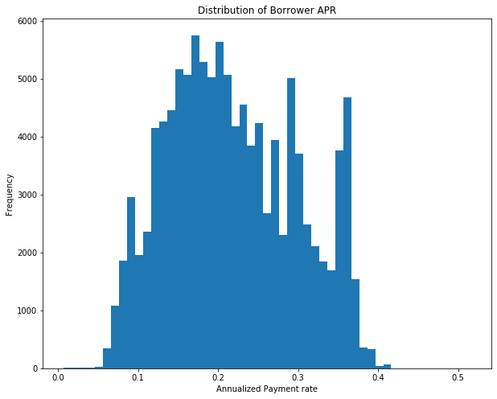

```python
plt.figure(figsize=(10,8))
APR_bins = np.arange(loan_clean.BorrowerAPR.min(), loan_clean.BorrowerAPR.max() +0.01, 0.01)
plt.hist(data = loan_clean, x = 'BorrowerAPR', bins = APR_bins)
graph_label('Annualized Payment rate','Frequency','Distribution of Borrower APR')
```

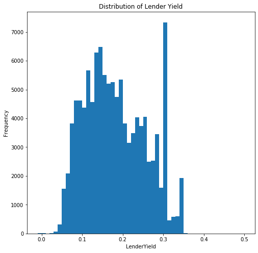

```python
plt.figure(figsize=(8,8))
yield_edges = np.arange(loan_clean.LenderYield.min(), loan_clean.LenderYield.max()+ 0.01, 0.01)
plt.hist(data = loan_clean, x = 'LenderYield', bins = yield_edges)
graph_label('LenderYield', 'Frequency', 'Distribution of Lender Yield')
```

```
(0, 1.5)
```

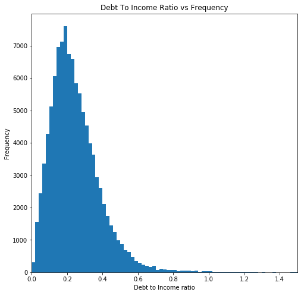

```python
# Distribution
graph_size(8,8)
bin_edges = np.arange(0, 10.01 + 0.02, 0.02)
plt.hist(data = loan_clean, x= 'DebtToIncomeRatio', bins = bin_edges)
graph_label('Debt to Income ratio', 'Frequency', 'Debt To Income Ratio vs Frequency')
plt.xlim((0,1.5))
```

## Distribution of Loan Amounts , Loan Status, Purpose and Employment Status:

> Loan Status : Majority of the loans are under the current status (56576) though many loans have been charged off , we do find that around 5018 loans are under the Default category and 1071 are 30 days past their interest/principal payments. Charged off and Defaulted can give us key insights on what trends determine the loan outcome status.

> Purpose: The above graph shows us that maximum number of loans are towards the purpose of "Debt Consolidation". Debt Consolidation means : consolidating all existing liabilities(loans) using unsecured ones with a loan. Debt consolidation loans don't erase the original debt but transfer a consumer's loans to a different lender or a type of a loan. Also, a huge chunk of loan is taken for 'Unknown' purposes, this needs further investigation as to how this affects the other variables.

> Employment Status : This shows that most of the loanees are employed. While the employment status of some people are unavailable. Few loans are taken by the 'Not employed' (probably student loans) and the 'Retired' sections as well.

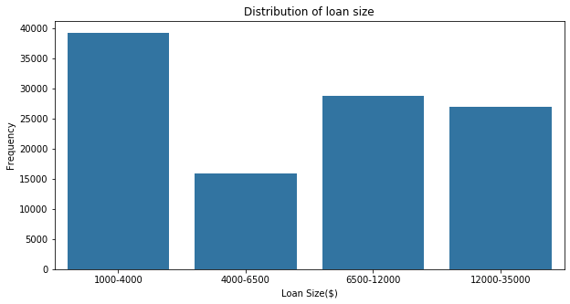

```python
graph_size(10,5)
sns.countplot(data = loan_clean, x = 'LoanSize', color = base_color);
graph_label('Loan Size($)', 'Frequency', 'Distribution of loan size')
```

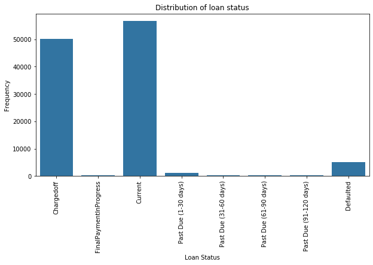

```python
graph_size(10,5)
sns.countplot(data = loan_clean , x ='LoanStatus', color = base_color);
plt.xticks(rotation = 90)
graph_label('Loan Status', 'Frequency', 'Distribution of loan status')
```

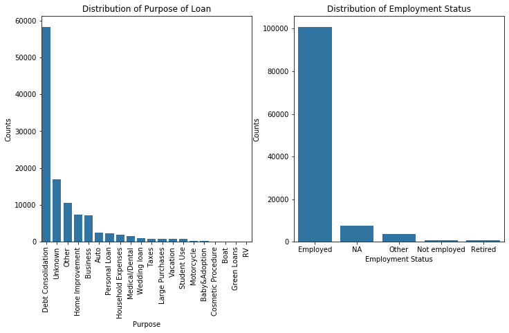

```python
#Since we are plotting nominal variables, the graph should display it in order of frequency:
purpose_order = loan_clean.PurposeOfLoan.value_counts().index

graph_size(12,6)
plt.subplot(1,2,1)
sns.countplot(data = loan_clean, x = 'PurposeOfLoan', color = base_color, order = purpose_order);
plt.xticks(rotation = 90)
graph_label('Purpose', 'Counts', 'Distribution of Purpose of Loan')
plt.subplot(1,2,2)
sns.countplot(data = loan_clean, x = 'EmploymentStatus', color = base_color);
graph_label('Employment Status', 'Counts', 'Distribution of Employment Status')
```

## Borrower APR vs Loan Size

> The BorrowerAPR is higher and more variable for lower range loans. It decreases with increase in Loan Amount. This anomaly of higher Borrower interest rates for lower loan sizes is because the smallest loan size of $(1000 - 4000) has the highest proportion of low ratings plus a huge chunk of these loans fall under the "unrated" category which points to a potential risk factor. This is irrespective of the fact that the differences between Debt to Income ratio of people opting for smaller loans is not significantly different from those opting larger loans.

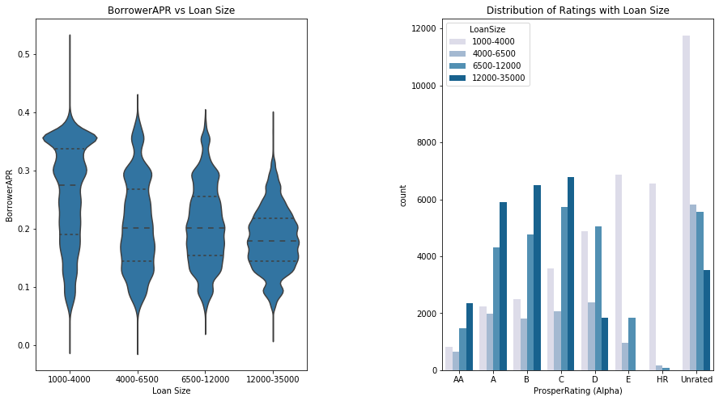

```python
#BorrowerAPR vs LoanSize
graph_size(15,8)
plt.subplot(1,2,1)
sns.violinplot(data = loan_clean, x = 'LoanSize', y = 'BorrowerAPR', color = base_color, inner = 'quartile')
graph_label('Loan Size', 'BorrowerAPR', 'BorrowerAPR vs Loan Size')
plt.subplot(1,2,2)
sns.set_palette("PuBu", 4)
sns.countplot(data = loan_clean, x = 'ProsperRating (Alpha)', hue = 'LoanSize');
plt.title('Distribution of Ratings with Loan Size')
plt.subplots_adjust(wspace = 0.5)
```

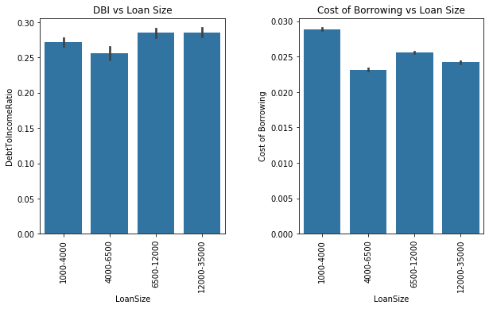

```python
# Plotting graphs to substantiate the anomaly observed above
graph_size(10,5)
plt.subplot(1,2,1)
sns.barplot(data = loan_clean, x = 'LoanSize', y = 'DebtToIncomeRatio', color = base_color);
graph_label('LoanSize', 'DebtToIncomeRatio', 'DBI vs Loan Size')
plt.xticks(rotation = 90)

plt.subplot(1,2,2)
sns.barplot(data = loan_clean, x = 'LoanSize', y = 'CostofBorrowing', color = base_color);
graph_label('LoanSize', 'Cost of Borrowing', 'Cost of Borrowing vs Loan Size')
plt.xticks(rotation = 90)

plt.subplots_adjust(wspace = 0.4)
```

## Borrower APR vs Income Range and Employment Status:

Is this anomaly because : Lower Income groups are taking heftier loans or because they have higher Debt To Income ratios?

The above anomaly remains largely unexplained that with increase in Income levels, the Borrower APR reduces. The Debt to Income ratio of loanees having incomes between $(25,000 to 100,000) is roughly the same. Since the unemployed section (which consists of students etc.) have no incomes, their DBI is higher.

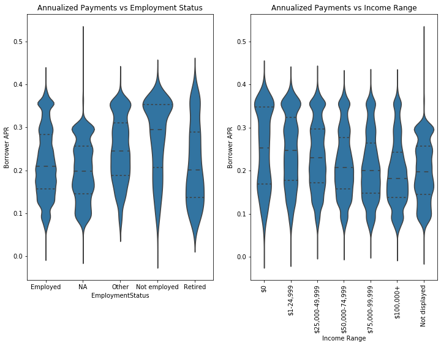

```python
#Borrower APR vs Income Range and Employment Status
graph_size(12,8)
plt.subplot(1,2,1)
sns.violinplot(data = loan_clean, x = 'EmploymentStatus', y = 'BorrowerAPR', color = base_color, inner = 'quartile')
graph_label('EmploymentStatus','Borrower APR' ,'Annualized Payments vs Employment Status')

plt.subplot(1,2,2)
sns.violinplot(data = loan_clean, x = 'IncomeRange', y = 'BorrowerAPR', color = base_color, inner = 'quartile')
plt.xticks(rotation = 90)
graph_label('Income Range', 'Borrower APR','Annualized Payments vs Income Range')
```

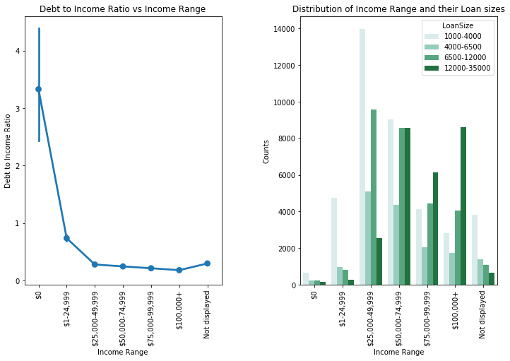

```python
#Investigating the above observation further
graph_size(12,7)
plt.subplot(1,2,1)
sns.pointplot(data = loan_clean, x = 'IncomeRange', y = 'DebtToIncomeRatio', color = base_color)
plt.xticks(rotation = 90)
graph_label('Income Range', 'Debt to Income Ratio', 'Debt to Income Ratio vs Income Range')

plt.subplot(1,2,2)
sns.set_palette("BuGn", 4)
sns.countplot(data = loan_clean, x = 'IncomeRange', hue = 'LoanSize')
plt.xticks(rotation = 90)
graph_label('Income Range', 'Counts', 'Distribution of Income Range and their Loan sizes')
plt.subplots_adjust(wspace = 0.4)
```

## Borrower APR vs Purpose of Loan along with the Income Ranges

1. The Borrower APR is lower for people with higher incomes.
2. The Borrower APR is amongst the lowest for *Debt Consolidation, Unknown, Personal Loans, Business and Student use*. However the gradation in the graph above shows that **for the same purpose of the loan, people with lower incomes pay higher interest rates.**
3. This is also true for loan sizes as we have seen above : **For the same sized loans, people with lower incomes pay higher interest rates.**

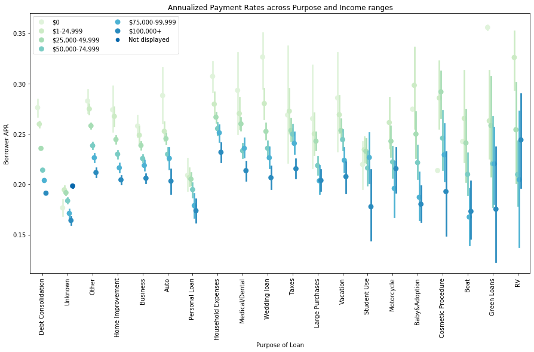

```python
graph_size(15,8)
sns.pointplot(data = loan_clean, x = 'PurposeOfLoan', y = 'BorrowerAPR', hue = 'IncomeRange', palette = 'GnBu', linestyles = '', dodge = 0.4, order = purpose_order)

plt.xticks(rotation = 90)
#Re-arranging legend to reduce over-lapping
plt.legend(ncol = 2)
graph_label('Purpose of Loan', 'Borrower APR', 'Annualized Payment Rates across Purpose and Income ranges')
```

## Borrower APR vs Purpose of Loan and their Loan Status

Borrower APR is different for different categories of loans. Delays in payment for Household expenses, Taxes, Large purchases, Green loans, RVs see higher charges. These loans might be risky but Debt Consolidation and loans for unknown purposes are the riskier groups.

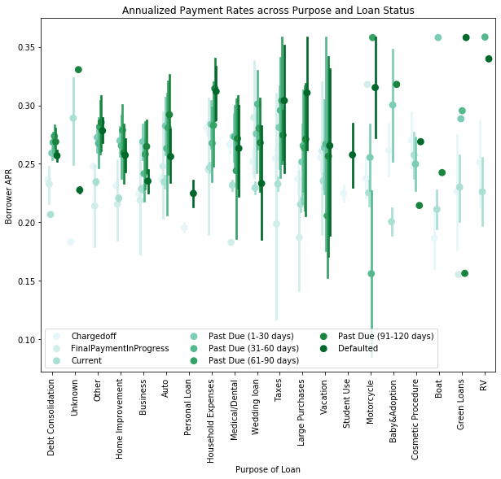

```python
graph_size(10,8)
sns.pointplot(data = loan_clean, x = 'PurposeOfLoan', y = 'BorrowerAPR', hue = 'LoanStatus',
           palette = 'BuGn', linestyles = '', dodge = 0.4, order = purpose_order);
plt.xticks(rotation = 90)

#Re-arranging legend to reduce over-lapping
plt.legend(ncol = 3)
graph_label('Purpose of Loan', 'Borrower APR', 'Annualized Payment Rates across Purpose and Loan Status')
```

## Borrower APR vs Loan Status and Employment Status

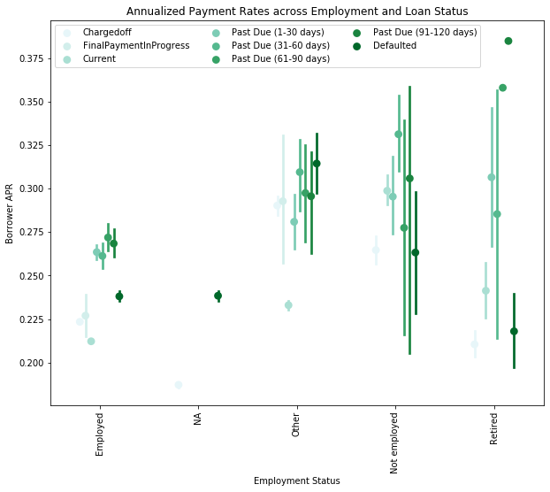

```python
graph_size(10,8)
sns.pointplot(data = loan_clean, x = 'EmploymentStatus', y = 'BorrowerAPR', hue = 'LoanStatus', palette = 'BuGn', linestyles = '', dodge = 0.4)

plt.xticks(rotation = 90)
#Re-arranging legend to reduce over-lapping
plt.legend(ncol = 3)

graph_label('Employment Status', 'Borrower APR', 'Annualized Payment Rates across Employment and Loan Status')
```

## Borrower APR vs Income Range and Loan Status

Lower income groups are paying higher charges for the same status of the loan. **These relationships are potentially due to** Unrated, Unknown purposes and Lack of employment status and income range** of the loanees. This anomaly can be rectified by addressing these.

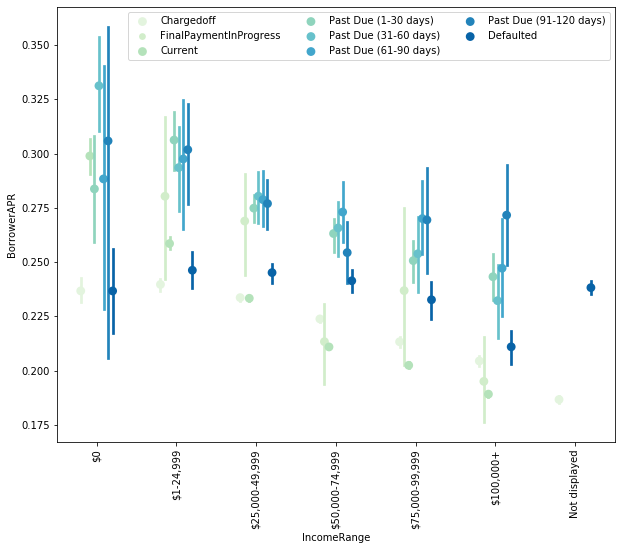

```python
graph_size(10,8)
sns.pointplot(data = loan_clean, x = 'IncomeRange', y = 'BorrowerAPR', hue = 'LoanStatus', palette = 'GnBu', linestyles = '', dodge = 0.4)

plt.xticks(rotation = 90)
#Re-arranging legend to reduce over-lapping
plt.legend(ncol = 3)
```

## Borrower APR vs Loan Size and Loan Status

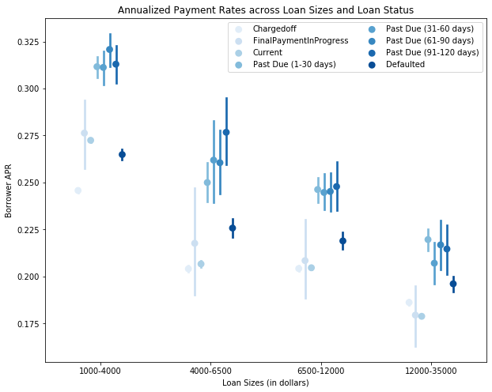

```python
graph_size(10,8)
sns.pointplot(data = loan_clean, x = 'LoanSize', y = 'BorrowerAPR', hue = 'LoanStatus',
           palette = 'Blues', linestyles = '' ,dodge = 0.4);

#Re-arranging legend to reduce over-lapping
plt.legend(ncol = 2, loc = 1)
graph_label('Loan Sizes (in dollars)', 'Borrower APR', 'Annualized Payment Rates across Loan Sizes and Loan Status')
```

## Loan Original Amount vs Credit Score and the Loan status

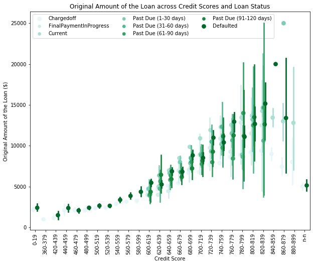

```python
graph_size(10,8)
sns.pointplot(data = loan_clean, x = 'CreditScore', y = 'LoanOriginalAmount', hue = 'LoanStatus',
           palette = 'BuGn', linestyles = '', dodge = 0.4);
plt.xticks(rotation = 90)

#Re-arranging legend to reduce over-lapping
plt.legend(ncol = 3)
graph_label('Credit Score', 'Original Amount of the Loan ($) ', 'Original Amount of the Loan across Credit Scores and Loan Status')
```

## Cost of Borrowing vs Prosper rating and their Loan Status

The cost of borrowing increases with decrease in the quality of rating however it has generally been higher for charged off and current loans than the delayed ones.

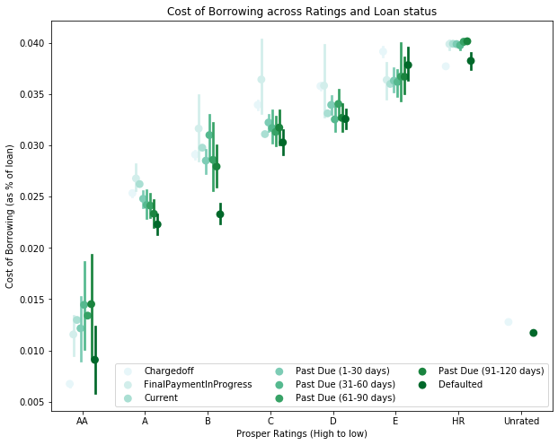

```python
graph_size(10,8)

sns.pointplot(data = loan_clean, x = 'ProsperRating (Alpha)', y = 'CostofBorrowing', hue = 'LoanStatus',
           palette = 'BuGn', linestyles = '', dodge = 0.4);

#Re-arranging legend to reduce over-lapping
plt.legend(ncol = 3)

graph_label('Prosper Ratings (High to low)', 'Cost of Borrowing (as % of loan)', 'Cost of Borrowing across Ratings and Loan status')
```